# Exam 01 Review

02.24.20

## The Data

For this exam review, we will analyze a sample of 300 diamonds that weigh less than 1.1 carats. The data is from the `diamonds` data set in the ggplot2 R package. Type `?ggplot2::diamonds` in the console to read more about the variables in this data set.

## Part I: Analysis of Variance

How much variation in `price` can be explained by the `clarity` of the diamond?

| term | df | sumsq | meansq | statistic | p.value |
| --- | --- | --- | --- | --- | --- |
| clarity | 7 | 79659890 | 11379984 | 3.398 | 0.002 |
| Residuals | 292 | 977793811 | 3348609 | NA | NA |

1. What is the estimated variance of the distribution of price within each level of clarity?
2. State the null and alternative hypotheses for the test conducted in the ANOVA table.
3. Briefly explain how the F test statistic is calculated.
4. State your conclusion for the test in (2) in the context of the data.
5. Briefly describe some of the next steps you would take in the analysis.

## Part II: Original Model

To better understand how different characteristics of a diamond affect its price, we fit a model with `price` as the response and `caratCent`, `depthCent`, `color`, and the interaction between `caratCent` and `color` as the predictor variables. `caratCent` is the mean-centered version of `carat` and `depthCent` is the mean-centered version of `depth`.

| term | estimate | std.error | statistic | p.value | conf.low | conf.high |
| --- | --- | --- | --- | --- | --- | --- |
| (Intercept) | 2592.722 | 122.824 | 21.109 | 0.000 | 2350.965 | 2834.479 |
| caratCent | 7100.854 | 476.744 | 14.894 | 0.000 | 6162.468 | 8039.241 |
| depthCent | 21.187 | 33.783 | 0.627 | 0.531 | -45.309 | 87.682 |
| colorE | -141.932 | 170.623 | -0.832 | 0.406 | -477.773 | 193.909 |
| colorF | -340.051 | 157.736 | -2.156 | 0.032 | -650.526 | -29.576 |
| colorG | -130.668 | 158.902 | -0.822 | 0.412 | -443.438 | 182.103 |
| colorH | -466.661 | 173.258 | -2.693 | 0.007 | -807.690 | -125.633 |
| colorI | -710.263 | 197.693 | -3.593 | 0.000 | -1099.388 | -321.139 |
| colorJ | -980.402 | 261.296 | -3.752 | 0.000 | -1494.717 | -466.086 |
| caratCent:colorE | -139.878 | 664.856 | -0.210 | 0.834 | -1448.530 | 1168.774 |
| caratCent:colorF | -1253.846 | 596.371 | -2.102 | 0.036 | -2427.696 | -79.996 |
| caratCent:colorG | -88.720 | 603.041 | -0.147 | 0.883 | -1275.699 | 1098.260 |
| caratCent:colorH | -1777.497 | 629.878 | -2.822 | 0.005 | -3017.299 | -537.695 |
| caratCent:colorI | -1832.264 | 739.703 | -2.477 | 0.014 | -3288.239 | -376.289 |
| caratCent:colorJ | -2267.281 | 1009.529 | -2.246 | 0.025 | -4254.361 | -280.202 |

1. Interpret `caratCent` and its 95% confidence interval in the context of the data.
2. Suppose you fit a new model that includes `carat` instead of `caratCent` as a predictor. All other predictors remain the same as in the model output above. Briefly describe how the estimate of the coefficient of `carat`, the corresponding test statistic, p-value, and confidence interval would compare to those shown in the model output above.
3. Interpret `colorF` and its 95% confidence interval in the context of the data.
4. Interpret `caratCent:colorF` and its 95% confidence interval in the context of the data.
5. Compare the interpretations in questions 3 and 4. Discuss the differences between `colorF` and `caratCent:colorF` and how they affect the model.
6. What are the assumptions of multiple linear regression? Some of the residuals plots used to check the model assumptions are shown below. For each plot, State the assumption(s) that can be assessed using that plot. Use the plot to determine if the assumption is satisfied.

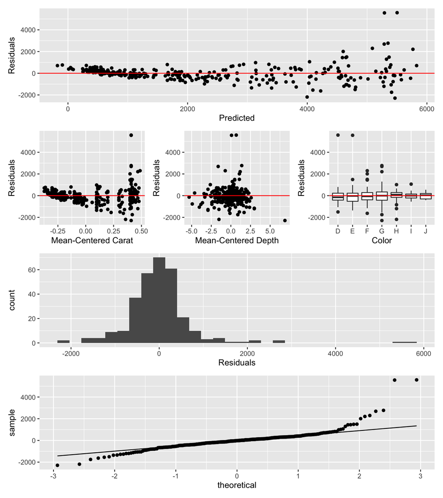

## Part III: Model with Log-Transformed Response

Next, we fit a model with the `log_price`, the log-transformed version of `price`, as the response variable. We use the same predictor variables as before.

| term | estimate | std.error | statistic | p.value | conf.low | conf.high |
| --- | --- | --- | --- | --- | --- | --- |
| (Intercept) | 7.533 | 0.037 | 201.531 | 0.000 | 7.459 | 7.606 |
| caratCent | 2.948 | 0.145 | 20.317 | 0.000 | 2.662 | 3.233 |
| depthCent | -0.004 | 0.010 | -0.355 | 0.723 | -0.024 | 0.017 |
| colorE | -0.045 | 0.052 | -0.868 | 0.386 | -0.147 | 0.057 |
| colorF | -0.100 | 0.048 | -2.087 | 0.038 | -0.195 | -0.006 |
| colorG | -0.048 | 0.048 | -0.988 | 0.324 | -0.143 | 0.047 |
| colorH | -0.226 | 0.053 | -4.288 | 0.000 | -0.330 | -0.122 |
| colorI | -0.295 | 0.060 | -4.912 | 0.000 | -0.414 | -0.177 |
| colorJ | -0.448 | 0.080 | -5.632 | 0.000 | -0.604 | -0.291 |
| caratCent:colorE | -0.042 | 0.202 | -0.210 | 0.834 | -0.441 | 0.356 |
| caratCent:colorF | -0.302 | 0.181 | -1.665 | 0.097 | -0.659 | 0.055 |
| caratCent:colorG | -0.130 | 0.184 | -0.710 | 0.478 | -0.492 | 0.231 |
| caratCent:colorH | -0.123 | 0.192 | -0.643 | 0.520 | -0.501 | 0.254 |
| caratCent:colorI | -0.044 | 0.225 | -0.195 | 0.846 | -0.487 | 0.399 |
| caratCent:colorJ | 0.053 | 0.307 | 0.173 | 0.863 | -0.552 | 0.658 |

1. Describe the subset of diamonds that are expected to have a median price of exp(7.533) = $1868.7.
2. Interpret the estimated coefficient of `depthCent` in terms of the price.
3. Write the model equation to predict `log(price)` for a diamond that’s color `D`.
4. Write the model equation to predict `log(price)` for a diamond that’s color `F`.
5. What is the slope of `caratCent` for a diamond with color `D`? Color `F`?
6. Describe how the price changes when going from a 1 carat diamond that’s color `D` with depth of 60 to a 0.5 carat diamond with color `F` and depth of 60.